# Introduction to the *scGini* R Package

```r
library(scGini)
library(ggplot2)
library(gridExtra)
```

`scGini` is built based on the concept that Gini index can be used to quantify the differentiation potency of single cells in scRNA-seq data. Generally, a larger Gini index implies a higher level of uneven distribution of the gene expression within a cell. Such a cell devotes most of its transcripts on a smaller spectrum of unique genes, and this in turn may reflect a more focused regulatory program, or a terminally differentiated state. By statistical approximation, `scGini` utilized a Negatibe-Binomial model to correct for the impact of library size in sparse counts data typically encountered in single cell RNA-seq and calculated the true Gini index for each single cell. More details about the method can be referred to the preprint.

## Installation

The latest version of `scGini` R package can be installed from Github.

```r
require(pbmcapply)
require(ineq)
require(ggplot2)
devtools::install_github("xianingz/scGini")
library(scGini)
```

## Example data

Here, we used a mouse germ cell dataset as an example for how to use `scGini`. This example dataset include 400 cells and 37,241 genes, with 100 cells from each of the Spermatogonia, Spermatocyte, Round Spermatid and Elongating Spermatid cell types.

```r
dim(mou.dat)
```

```
#> [1] 37241   400
```

The input data for `scGini` would need to be the raw expression data without any normalization or transformation. You can use either the full set of genes you have or protein-coding genes only. Both gene sets showed similar results in our analysis.

```r
mou.dat[1:5,1:5]
```

```
#>               ST2_CTCGACATTACT ST7_ACGTTCGGTGAG ST4_TATATGTCTAGN SPG3_CCAGTGCTAGGC
#> 0610005C13Rik                0                0                0                 0
#> 0610007P14Rik                0                0                0                 0
#> 0610009B22Rik                0                0                1                 0
#> 0610009E02Rik                0                0                0                 0
#> 0610009L18Rik                1                0                0                 0
#>               SPG3_AATGGGACTCTN
#> 0610005C13Rik                 0
#> 0610007P14Rik                 3
#> 0610009B22Rik                 1
#> 0610009E02Rik                 0
#> 0610009L18Rik                 0
```

## Goodness of fit

Before applying `scGini` to the full dataset, we recommend a diagnosis of the goodness of fit for individual cells randomly selected from your sample. `NBFitPlot` will estimate the model parameters from the data and draw a plot with both observed count frequencies and theoretical probabilities to show the goodness of fit. Proceed to use `scGini` only when a satisfying fitting can be obtained.

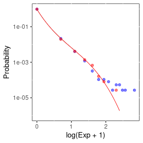

```r
NBFitPlot(mou.dat[,1], seed=1)
```

## Calculation of corrected Gini index

```r
mou.cgini <- scGini(mou.dat, ncore = 4)
head(mou.cgini)
```

[output not shown]

In the returned data frame, there are five columns  
`eta`, `alpha`: $\eta$ and $\alpha$ parameters in the negative binomial model estimated from observed data.  
`Iter`: The number of iterations before convergence.  
`Gini`: The Gini index calculated directly from the data  
`cGini`: Corrected Gini index calculated by scGini

## Neighborhood smoothing

The results from `scGini` can be further improved by borrowing information from neighboring cells. `scGiniSmooth` functions implements a neighborhood difussion map to improve the scGini prediction.

```r
sGini <- scGiniSmooth(mou.dat, mou.cgini$cGini, nGenes=1000)
```

Comparison of Gini index without correction, corrected Gini index and smoothed corrected Gini index

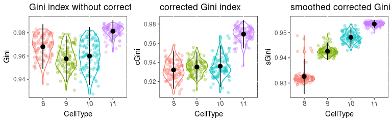

```r
df.mou.pc <- data.frame(nUMIs=mou.numis, cGini=mou.cgini$cGini, Gini=mou.cgini$Gini,  sGini=sGini, CellType=as.factor(mou.label))
p1 <- ggplot(df.mou.pc, aes(CellType, Gini, color=CellType)) + geom_violin(scale = "width") + geom_jitter(alpha=0.3) + stat_summary(fun.data="mean_sdl", geom="pointrange", color="black")+ theme(panel.background = element_rect(fill = "white", colour = "black"), axis.text.x = element_text(angle=10, hjust = 0.6, size=10),legend.position = "none") + ggtitle("Gini index without correction")
p2 <- ggplot(df.mou.pc, aes(CellType, cGini, color=CellType)) + geom_violin(scale = "width") + geom_jitter(alpha=0.3) + stat_summary(fun.data="mean_sdl", geom="pointrange", color="black") + theme(panel.background = element_rect(fill = "white", colour = "black"), axis.text.x = element_text(angle=10, hjust = 0.6, size=10),legend.position = "none")+ ggtitle("corrected Gini index")
p3 <- ggplot(df.mou.pc, aes(CellType, sGini, color=CellType)) + geom_violin(scale = "width") + geom_jitter(alpha=0.3) + stat_summary(fun.data="mean_sdl", geom="pointrange", color="black")+ theme(panel.background = element_rect(fill = "white", colour = "black"), axis.text.x = element_text(angle=10, hjust = 0.6, size=10),legend.position = "none")+ ggtitle("smoothed corrected Gini index")
do.call("grid.arrange", c(list(p1,p2,p3), ncol=3))
```